# Final Presentation

May 13th 2025

Frederik Spors

## Project 1 - Data Visualization

- Overview
- Flight per Month
- CO2 Emission
- Two TidyTuesday datasets
- Data on the total number of flights per month (2010-2018)
- Data on the change in CO2 emission

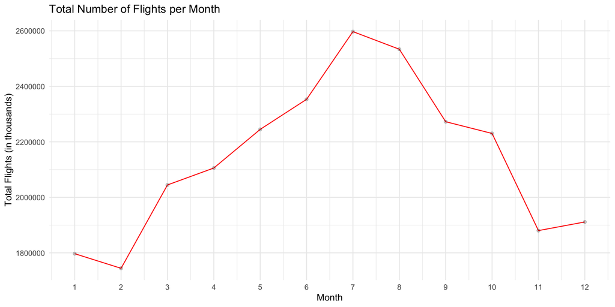

```r
ggplot(monthly_totals, aes(x = Month, y = total_flights)) +
  geom_line(color = "red") +
  geom_point(alpha = 0.2) +
  labs(title = "Total Number of Flights per Month",
       x = "Month",
       y = "Total Flights (in thousands)") +
  theme_minimal() +
  scale_x_continuous(breaks = 1:12, labels = 1:12)
```

- Data from 90 countries from 2010-2018
- Number of flights peak in the summer

EUROCONTROL. (2025). *European Air Navigation Performance Review Reports*. Original source: https://ansperformance.eu/data/  
Accessed via TidyTuesday GitHub repository: [GitHub Repository](https://github.com/rfordatascience/tidytuesday/blob/main/data/2022/2022-07-12/readme.md)

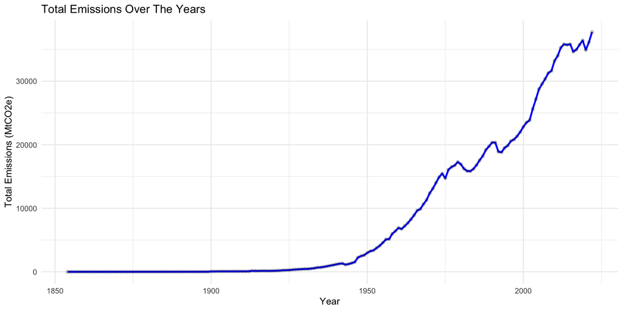

```r
ggplot(annual_emissions, aes(x = year, y = total_emissions)) +
  geom_line(color = "blue", size = 1) +
  geom_point(alpha = 0.2) +
  labs(title = "Total Emissions Over The Years",
       x = "Year",
       y = "Total Emissions (MtCO2e)") +
  theme_minimal()
```

- Global emissions have increased drastically since 1950
- Caused by rapid industrialization and increased reliance on fossil fuels

Climate Accountability Institute. (2023). *Carbon Majors Database*. Original source: https://carbonmajors.org/  
Accessed via TidyTuesday GitHub repository: [GitHub Repository](https://github.com/rfordatascience/tidytuesday/blob/main/data/2024/2024-05-21/readme.md)

## Comparing Traffic Violations using SQL

- Overview
- Age Distribution
- Frequency of Stops
- Grouped individuals into five age brackets to compare stop distributions in Madison (WI), Mesa (AZ) and Aurora (CO)
- Investigated most common traffic violations per city to assess enforcement patterns and demographic trends
- Applied different violation-count thresholds to highlight top violations in each city, accounting for differences in population and data size

Pierson, E., Simoiu, C., Overgoor, J., Corbett-Davies, S., Jenson, D., Shoemaker, A., Ramachandran, V., Goel, S., et al. (2020). *A Large-Scale Analysis of Racial Disparities in Police Stops Across the United States*. *Nature Human Behaviour*, 1–10.

```sql
SELECT
  state,
  CASE
    WHEN subject_age < 18 THEN '<18'
    WHEN subject_age BETWEEN 18 AND 30 THEN '18-30'
    WHEN subject_age BETWEEN 31 AND 45 THEN '31-45'
    WHEN subject_age BETWEEN 46 AND 65 THEN '46-60'
    ELSE '60+'
  END AS age_group,
  COUNT(*) AS stop_count
FROM (
  SELECT 'Madison' AS state, subject_age
  FROM wi_madison_2023_01_26
  WHERE subject_age IS NOT NULL

  UNION ALL

  SELECT 'Mesa' AS state, subject_age
  FROM az_mesa_2023_01_26
  WHERE subject_age IS NOT NULL

  UNION ALL

  SELECT 'Aurora' AS state, subject_age
  FROM co_aurora_2023_01_26
  WHERE subject_age IS NOT NULL) AS combined
GROUP BY state, age_group
ORDER BY state, age_group;
```

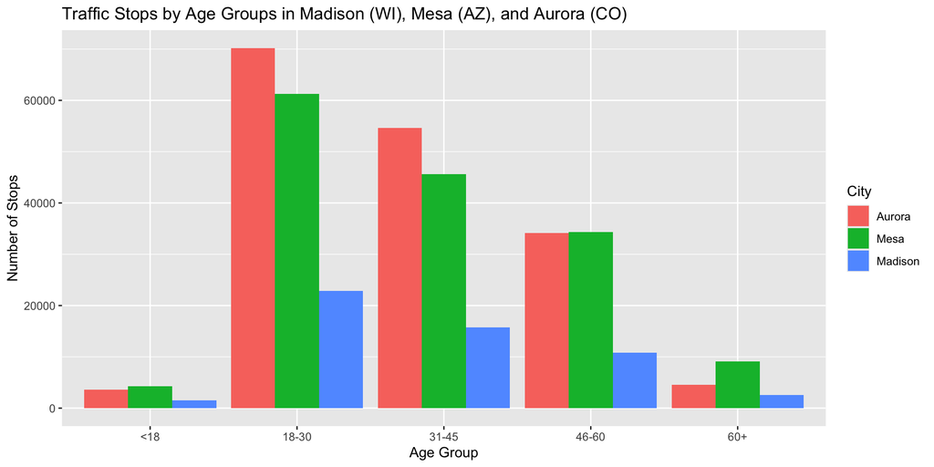

- Ages 18–30 and 31–45 had the highest number of stops in all three cities
- Aurora had the most stops overall, especially among younger drivers
- Madison had fewer stops across all age groups, likely due to lower traffic volume or less policing

**Type of Traffic Violations in Madison, WI**

```
                                     violation violation_count
1       EXCEEDING SPEED ZONES, ETC. (1-10 MPH)           33740
2 OPERATE MOTOR VEHICLE W/O PROOF OF INSURANCE           23636
3      EXCEEDING SPEED ZONES, ETC. (11-15 MPH)           16533
4                   OPERATING AFTER SUSPENSION           12309
5         VEHICLE OPERATOR FAIL/WEAR SEAT BELT           12074
6        SPEEDING OVER FIXED LIMITS (1-10 MPH)           10574
7             AUTOMOBILE FOLLOWING TOO CLOSELY           10169
8                   VIOLATE RED TRAFFIC SIGNAL            9826
9                NON-REGISTRATION OF AUTO, ETC            9423
```

**Type of Traffic Violations in Mesa, AZ**

```
                                      violation violation_count
1  SPEED NOT R&P/FTC SPEED TO AVOID A COLLISION           58480
2                          EXPIRED REGISTRATION            9349
3                         NO PROOF OF INSURANCE            6163
4    NO VALID DRIVERS LICENSE - IN/OUT OF STATE            5083
5                 M / I SUSPENSION REGISTRATION            4884
6                           RED LIGHT VIOLATION            4669
7                 FAILURE TO STOP FOR STOP SIGN            3534
8           FAILURE OBEY TRAFFIC CONTROL DEVICE            3376
9              TWO HEADLIGHTS REQUIRED AT NIGHT            3246
10        DRIVE ON SUSPENDED OR REVOKED LICENSE            3221
```

**Type of Traffic Violations in Aurora, CO**

```
                                             violation violation_count
1                                Speeding (10-19 Over)           75246
2                       Speeding (10-14 Over 65 Limit)           27967
3 Failed to Present Evidence of Insurance Upon Request           18460
4                                Disregarded Stop Sign            8661
5               Speeding (20+ Over) - Muni Statue 1101            8310
6          Failed to Obey Seat Belt Requirements Adult            8129
7                                     Careless Driving            7459
8                Failed to Obey Seat Belt Requirements            7024
9                               Expired License Plates            5892
```

**Summary**

- Speeding is the most frequent violation in all three cities
- Enforcement and violation categories differ significantly
- Younger drivers (18–45) dominate traffic stops, aligning with riskier behavior trends

# Thank You!

[Back to Website](https://fredsp05.github.io/FrederikSpors)